# What affects the borrower's interest rate?

## by Fatima Elmalla

## Investigation Overview

> the dataset was invistigated to find the features that affect the interest rate of the borrower. the analysis focused on the following variables: Term, ListingCategory, EmploymentStatus, ProsperRating,StatedMonthlyIncome, LoanOriginalAmount. this presentation is going to focus on the features that was found to actually affect the interest rate.

## Dataset Overview

> This data set contains 113,937 loans with 81 variables on each loan, including loan amount, borrower rate (or interest rate), current loan status, borrower income, and many others. This project is going to focus on the interest rate and its realtion to the following variables: Term, ListingCategory, EmploymentStatus, ProsperRating,StatedMonthlyIncome, LoanOriginalAmount.

## Distribution of borrower's interest rate

> the distibution of the borrower's rate looks multimodal with a peak between 0.1 and 0.2 and the highest peak between 0.3 and 0.31.

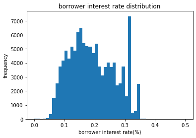

```python
#Distribution of borrower interest rate
bins = np.arange(0, df_sub['BorrowerRate'].max()+0.01, 0.01)
plt.hist(data = df_sub, x = 'BorrowerRate', bins = bins);
plt.title('borrower interest rate distribution');
plt.xlabel('borrower interest rate(%)')
plt.ylabel('frequency');
```

## Distribution of Stated Monthly Income

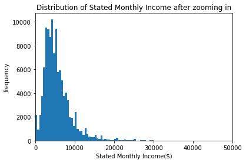

```python
#Distribution of Stated Monthly Income after zooming in
bins = np.arange(0, df_sub['StatedMonthlyIncome'].max()+500, 500)
plt.hist(data = df_sub, x = 'StatedMonthlyIncome', bins = bins);
plt.title('Distribution of Stated Monthly Income after zooming in');
plt.xlim([0,50000]);
plt.xlabel('Stated Monthly Income($)')
plt.ylabel('frequency');
```

## Distribution of Loan Original Amount

> the graph has very high peaks at 4K, 10K, and 15K. and relatively low peaks at 1k,2k,3k,20k and 25k. The graph looks multiodal.

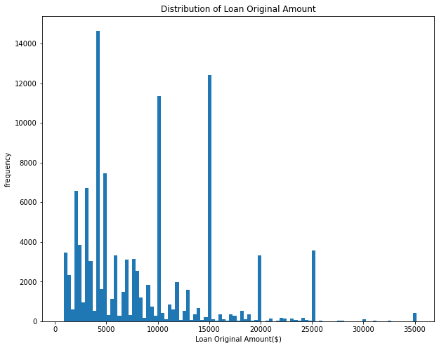

```python
#Distribution of Loan Original Amount
plt.figure(figsize=[10,8])
bins = np.arange(500, df_sub['LoanOriginalAmount'].max()+350, 350)
plt.hist(data = df_sub, x = 'LoanOriginalAmount', bins = bins);
plt.title('Distribution of Loan Original Amount');
plt.xlabel('Loan Original Amount($)')
plt.ylabel('frequency');
```

## Borrower rate vs Loan Original Amount

> the graph shows a negative corelation between borrower interest rate and loan original amount. the interest rate increase with the decrease of the original amount of the loan.

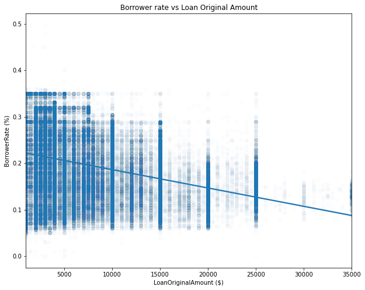

```python
#drawing the Borrower rate vs Loan Original Amount
plt.figure(figsize=[10,8])
sb.regplot(data = df_sub, x = 'LoanOriginalAmount', y = 'BorrowerRate', scatter_kws={'alpha':0.01});
plt.xlabel('LoanOriginalAmount ($)')
plt.ylabel('BorrowerRate (%)')
plt.title('Borrower rate vs Loan Original Amount');
```

## Borrower rate vs Stated Monthly Income

> Most of the loaner's monthly income are between 2k and 10k dollars. the graph shows a negative corelation between borrower interest rate and Stated Monthly Income. the inerest rate of the borrower's decreases with the increase of the monthly income of the borrower.

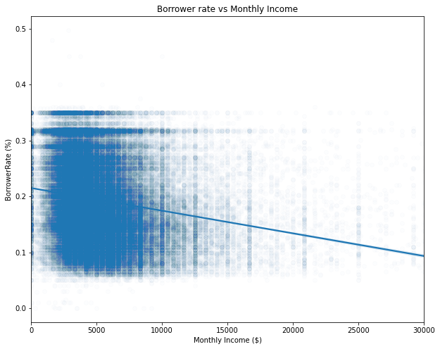

```python
#drawing Borrower rate vs Stated Monthly Income
plt.figure(figsize=[10,8])
sb.regplot(data = df_sub, x = 'StatedMonthlyIncome', y = 'BorrowerRate', scatter_kws={'alpha':0.01});
plt.xlabel('Monthly Income ($)')
plt.ylabel('BorrowerRate (%)');
plt.title('Borrower rate vs Monthly Income');
```

## Borrower's rate vs Prosper Rating

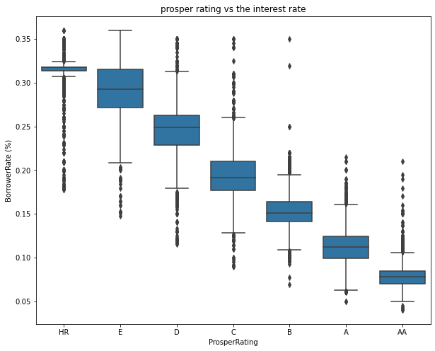

```python
#plotting the relation between the prosper rating and the interest rate
plt.figure(figsize=[10,8])
sb.boxplot(data=df_sub, x='ProsperRating', y='BorrowerRate', color=base_color)
plt.title('prosper rating vs the interest rate');
plt.xlabel('ProsperRating')
plt.ylabel('BorrowerRate (%)');
```

## Interest rate vs loan amount vs prosper rating

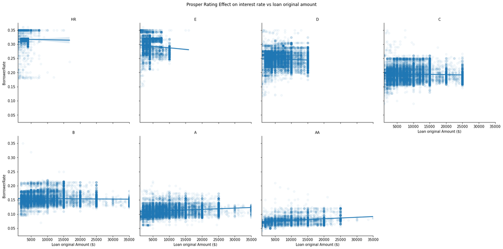

```python
#plotting interest rate vs loan amount vs prosper rating
g = sb.FacetGrid(data = df_sub, col = 'ProsperRating', height = 5, col_wrap=4,
                margin_titles = True)
g.map(sb.regplot, 'LoanOriginalAmount', 'BorrowerRate', scatter_kws={'alpha':0.05});
g.set_xlabels('Loan original Amount ($)')
g.set_ylabels('BorrowerRate')
plt.suptitle('Prosper Rating Effect on interest rate vs loan original amount');
plt.subplots_adjust(top=0.90)
g.set_titles('{col_name}');
```

## ProsperRating vs Term vs interest rate

> the higher the term value the higher the interest rate in each prosper rating category.

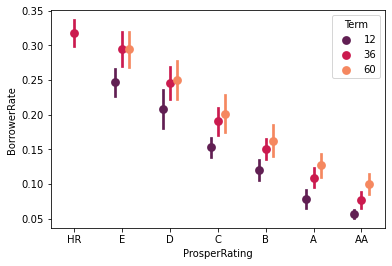

```python
#plotting ProsperRating vs Term vs interest rate
ax = sb.pointplot(data = df_sub, x = 'ProsperRating', y = 'BorrowerRate', hue = 'Term',
                  dodge = 0.3, linestyles = "", ci='sd', palette="rocket");
```

## Interest rate vs monthly income vs employment status

> self-employed borrowers show less negative relationship between interest rate and the monthly income of the borrower.

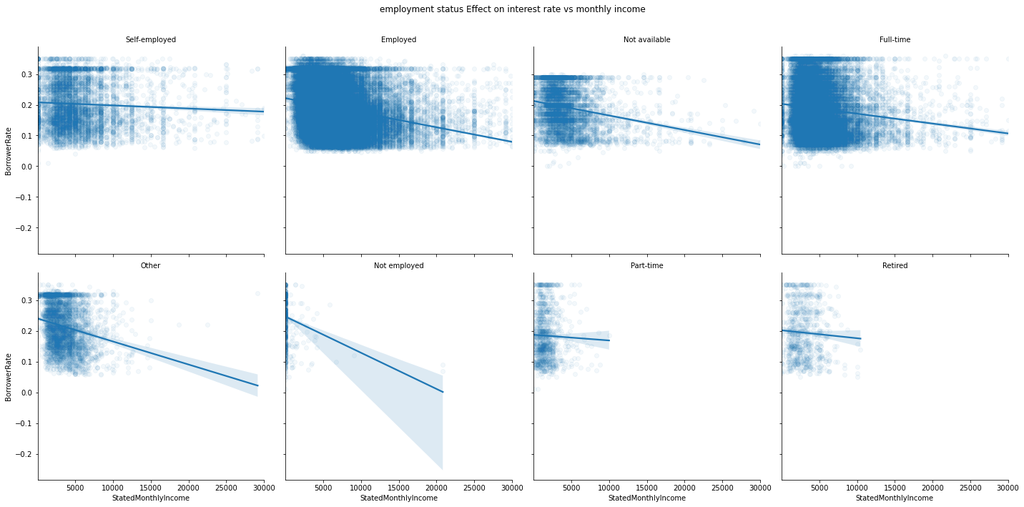

```python
#plotting Interest rate vs monthly income vs employment status
g = sb.FacetGrid(data = df_sub, col = 'EmploymentStatus', height = 5, col_wrap=4,
                margin_titles = True)
g.map(sb.regplot, 'StatedMonthlyIncome', 'BorrowerRate', scatter_kws={'alpha':0.05});
plt.suptitle('employment status Effect on interest rate vs monthly income');
plt.subplots_adjust(top=0.90)
g.set_titles('{col_name}');
```

```python
!jupyter nbconvert presentation.ipynb --to slides --no-input
```

```
[NbConvertApp] Converting notebook presentation.ipynb to slides
[NbConvertApp] Writing 1805308 bytes to presentation.slides.html
```